# **Progress Report II: Output**

Valeria Salinas-Lopez

4/24/2021

### Libraries

```r
library(stargazer)
library(Hmisc)
library(plm)
library(dplyr)
library(FSelector)
library(rpart)
library(caret)
library(rpart.plot)
library(data.tree)
library(caTools)
```

### Set Working Directory

```r
setwd("/Users/valer/OneDrive/Documents/Spring 2021/KM")
```

### Load in the Data

```r
mydata <- read.csv("/Users/valer/OneDrive/Documents/Spring 2021/KM/KMdata.csv")
```

# **Making each region a dummy variable**

## List of every region

```r
table(mydata$region)
```

```
##
##          Caribbean     Central Africa    Central America        East Africa
##                  1                  1                  3                  2
##       Eastern Asia     Eastern Europe       North Africa      North America
##                  2                  2                  2                 19
## South-Central Asia      South America     Southeast Asia        West Africa
##                 28                  1                  8                  5
##       Western Asia     Western Europe
##                  4                  1
```

## Used this code to create each dummy variable

```r
mydata$carib[mydata$region=="Caribbean"] <- 1
mydata$carib[mydata$region=="Central Africa"] <- 0
mydata$carib[mydata$region=="Central America"] <- 0
mydata$carib[mydata$region=="East Africa"] <- 0
mydata$carib[mydata$region=="Eastern Asia"] <- 0
mydata$carib[mydata$region=="Eastern Europe"] <- 0
mydata$carib[mydata$region=="North Africa"] <- 0
mydata$carib[mydata$region=="North America"] <- 0
mydata$carib[mydata$region=="South-Central Asia"] <- 0
mydata$carib[mydata$region=="South America"] <- 0
mydata$carib[mydata$region=="Southeast Asia"] <- 0
mydata$carib[mydata$region=="West Africa"] <- 0
mydata$carib[mydata$region=="Western Asia"] <- 0
mydata$carib[mydata$region=="Western Europe"] <- 0

mydata$centaf[mydata$region=="Caribbean"] <- 0
mydata$centaf[mydata$region=="Central Africa"] <- 1
mydata$centaf[mydata$region=="Central America"] <- 0
mydata$centaf[mydata$region=="East Africa"] <- 0
mydata$centaf[mydata$region=="Eastern Asia"] <- 0
mydata$centaf[mydata$region=="Eastern Europe"] <- 0
mydata$centaf[mydata$region=="North Africa"] <- 0
mydata$centaf[mydata$region=="North America"] <- 0
mydata$centaf[mydata$region=="South-Central Asia"] <- 0
mydata$centaf[mydata$region=="South America"] <- 0
mydata$centaf[mydata$region=="Southeast Asia"] <- 0
mydata$centaf[mydata$region=="West Africa"] <- 0
mydata$centaf[mydata$region=="Western Asia"] <- 0
mydata$centaf[mydata$region=="Western Europe"] <- 0

mydata$centam[mydata$region=="Caribbean"] <- 0
mydata$centam[mydata$region=="Central Africa"] <- 0
mydata$centam[mydata$region=="Central America"] <- 1
mydata$centam[mydata$region=="East Africa"] <- 0
mydata$centam[mydata$region=="Eastern Asia"] <- 0
mydata$centam[mydata$region=="Eastern Europe"] <- 0
mydata$centam[mydata$region=="North Africa"] <- 0
mydata$centam[mydata$region=="North America"] <- 0
mydata$centam[mydata$region=="South-Central Asia"] <- 0
mydata$centam[mydata$region=="South America"] <- 0
mydata$centam[mydata$region=="Southeast Asia"] <- 0
mydata$centam[mydata$region=="West Africa"] <- 0
mydata$centam[mydata$region=="Western Asia"] <- 0
mydata$centam[mydata$region=="Western Europe"] <- 0

mydata$eaaf[mydata$region=="Caribbean"] <- 0
mydata$eaaf[mydata$region=="Central Africa"] <- 0
mydata$eaaf[mydata$region=="Central America"] <- 0
mydata$eaaf[mydata$region=="East Africa"] <- 1
mydata$eaaf[mydata$region=="Eastern Asia"] <- 0
mydata$eaaf[mydata$region=="Eastern Europe"] <- 0
mydata$eaaf[mydata$region=="North Africa"] <- 0
mydata$eaaf[mydata$region=="North America"] <- 0
mydata$eaaf[mydata$region=="South-Central Asia"] <- 0
mydata$eaaf[mydata$region=="South America"] <- 0
mydata$eaaf[mydata$region=="Southeast Asia"] <- 0
mydata$eaaf[mydata$region=="West Africa"] <- 0
mydata$eaaf[mydata$region=="Western Asia"] <- 0
mydata$eaaf[mydata$region=="Western Europe"] <- 0

mydata$eaas[mydata$region=="Caribbean"] <- 0
mydata$eaas[mydata$region=="Central Africa"] <- 0
mydata$eaas[mydata$region=="Central America"] <- 0
mydata$eaas[mydata$region=="East Africa"] <- 0
mydata$eaas[mydata$region=="Eastern Asia"] <- 1
mydata$eaas[mydata$region=="Eastern Europe"] <- 0
mydata$eaas[mydata$region=="North Africa"] <- 0
mydata$eaas[mydata$region=="North America"] <- 0
mydata$eaas[mydata$region=="South-Central Asia"] <- 0
mydata$eaas[mydata$region=="South America"] <- 0
mydata$eaas[mydata$region=="Southeast Asia"] <- 0
mydata$eaas[mydata$region=="West Africa"] <- 0
mydata$eaas[mydata$region=="Western Asia"] <- 0
mydata$eaas[mydata$region=="Western Europe"] <- 0

mydata$eaeu[mydata$region=="Caribbean"] <- 0
mydata$eaeu[mydata$region=="Central Africa"] <- 0
mydata$eaeu[mydata$region=="Central America"] <- 0
mydata$eaeu[mydata$region=="East Africa"] <- 0
mydata$eaeu[mydata$region=="Eastern Asia"] <- 0
mydata$eaeu[mydata$region=="Eastern Europe"] <- 1
mydata$eaeu[mydata$region=="North Africa"] <- 0
mydata$eaeu[mydata$region=="North America"] <- 0
mydata$eaeu[mydata$region=="South-Central Asia"] <- 0
mydata$eaeu[mydata$region=="South America"] <- 0
mydata$eaeu[mydata$region=="Southeast Asia"] <- 0
mydata$eaeu[mydata$region=="West Africa"] <- 0
mydata$eaeu[mydata$region=="Western Asia"] <- 0
mydata$eaeu[mydata$region=="Western Europe"] <- 0

mydata$noraf[mydata$region=="Caribbean"] <- 0
mydata$noraf[mydata$region=="Central Africa"] <- 0
mydata$noraf[mydata$region=="Central America"] <- 0
mydata$noraf[mydata$region=="East Africa"] <- 0
mydata$noraf[mydata$region=="Eastern Asia"] <- 0
mydata$noraf[mydata$region=="Eastern Europe"] <- 0
mydata$noraf[mydata$region=="North Africa"] <- 1
mydata$noraf[mydata$region=="North America"] <- 0
mydata$noraf[mydata$region=="South-Central Asia"] <- 0
mydata$noraf[mydata$region=="South America"] <- 0
mydata$noraf[mydata$region=="Southeast Asia"] <- 0
mydata$noraf[mydata$region=="West Africa"] <- 0
mydata$noraf[mydata$region=="Western Asia"] <- 0
mydata$noraf[mydata$region=="Western Europe"] <- 0

mydata$noram[mydata$region=="Caribbean"] <- 0
mydata$noram[mydata$region=="Central Africa"] <- 0
mydata$noram[mydata$region=="Central America"] <- 0
mydata$noram[mydata$region=="East Africa"] <- 0
mydata$noram[mydata$region=="Eastern Asia"] <- 0
mydata$noram[mydata$region=="Eastern Europe"] <- 0
mydata$noram[mydata$region=="North Africa"] <- 0
mydata$noram[mydata$region=="North America"] <- 1
mydata$noram[mydata$region=="South-Central Asia"] <- 0
mydata$noram[mydata$region=="South America"] <- 0
mydata$noram[mydata$region=="Southeast Asia"] <- 0
mydata$noram[mydata$region=="West Africa"] <- 0
mydata$noram[mydata$region=="Western Asia"] <- 0
mydata$noram[mydata$region=="Western Europe"] <- 0

mydata$csas[mydata$region=="Caribbean"] <- 0
mydata$csas[mydata$region=="Central Africa"] <- 0
mydata$csas[mydata$region=="Central America"] <- 0
mydata$csas[mydata$region=="East Africa"] <- 0
mydata$csas[mydata$region=="Eastern Asia"] <- 0
mydata$csas[mydata$region=="Eastern Europe"] <- 0
mydata$csas[mydata$region=="North Africa"] <- 0
mydata$csas[mydata$region=="North America"] <- 0
mydata$csas[mydata$region=="South-Central Asia"] <- 1
mydata$csas[mydata$region=="South America"] <- 0
mydata$csas[mydata$region=="Southeast Asia"] <- 0
mydata$csas[mydata$region=="West Africa"] <- 0
mydata$csas[mydata$region=="Western Asia"] <- 0
mydata$csas[mydata$region=="Western Europe"] <- 0

mydata$sam[mydata$region=="Caribbean"] <- 0
mydata$sam[mydata$region=="Central Africa"] <- 0
mydata$sam[mydata$region=="Central America"] <- 0
mydata$sam[mydata$region=="East Africa"] <- 0
mydata$sam[mydata$region=="Eastern Asia"] <- 0
mydata$sam[mydata$region=="Eastern Europe"] <- 0
mydata$sam[mydata$region=="North Africa"] <- 0
mydata$sam[mydata$region=="North America"] <- 0
mydata$sam[mydata$region=="South-Central Asia"] <- 0
mydata$sam[mydata$region=="South America"] <- 1
mydata$sam[mydata$region=="Southeast Asia"] <- 0
mydata$sam[mydata$region=="West Africa"] <- 0
mydata$sam[mydata$region=="Western Asia"] <- 0
mydata$sam[mydata$region=="Western Europe"] <- 0

mydata$seas[mydata$region=="Caribbean"] <- 0
mydata$seas[mydata$region=="Central Africa"] <- 0
mydata$seas[mydata$region=="Central America"] <- 0
mydata$seas[mydata$region=="East Africa"] <- 0
mydata$seas[mydata$region=="Eastern Asia"] <- 0
mydata$seas[mydata$region=="Eastern Europe"] <- 0
mydata$seas[mydata$region=="North Africa"] <- 0
mydata$seas[mydata$region=="North America"] <- 0
mydata$seas[mydata$region=="South-Central Asia"] <- 0
mydata$seas[mydata$region=="South America"] <- 0
mydata$seas[mydata$region=="Southeast Asia"] <- 1
mydata$seas[mydata$region=="West Africa"] <- 0
mydata$seas[mydata$region=="Western Asia"] <- 0
mydata$seas[mydata$region=="Western Europe"] <- 0

mydata$waf[mydata$region=="Caribbean"] <- 0
mydata$waf[mydata$region=="Central Africa"] <- 0
mydata$waf[mydata$region=="Central America"] <- 0
mydata$waf[mydata$region=="East Africa"] <- 0
mydata$waf[mydata$region=="Eastern Asia"] <- 0
mydata$waf[mydata$region=="Eastern Europe"] <- 0
mydata$waf[mydata$region=="North Africa"] <- 0
mydata$waf[mydata$region=="North America"] <- 0
mydata$waf[mydata$region=="South-Central Asia"] <- 0
mydata$waf[mydata$region=="South America"] <- 0
mydata$waf[mydata$region=="Southeast Asia"] <- 0
mydata$waf[mydata$region=="West Africa"] <- 1
mydata$waf[mydata$region=="Western Asia"] <- 0
mydata$waf[mydata$region=="Western Europe"] <- 0

mydata$was[mydata$region=="Caribbean"] <- 0
mydata$was[mydata$region=="Central Africa"] <- 0
mydata$was[mydata$region=="Central America"] <- 0
mydata$was[mydata$region=="East Africa"] <- 0
mydata$was[mydata$region=="Eastern Asia"] <- 0
mydata$was[mydata$region=="Eastern Europe"] <- 0
mydata$was[mydata$region=="North Africa"] <- 0
mydata$was[mydata$region=="North America"] <- 0
mydata$was[mydata$region=="South-Central Asia"] <- 0
mydata$was[mydata$region=="South America"] <- 0
mydata$was[mydata$region=="Southeast Asia"] <- 0
mydata$was[mydata$region=="West Africa"] <- 0
mydata$was[mydata$region=="Western Asia"] <- 1
mydata$was[mydata$region=="Western Europe"] <- 0

mydata$weu[mydata$region=="Caribbean"] <- 0
mydata$weu[mydata$region=="Central Africa"] <- 0
mydata$weu[mydata$region=="Central America"] <- 0
mydata$weu[mydata$region=="East Africa"] <- 0
mydata$weu[mydata$region=="Eastern Asia"] <- 0
mydata$weu[mydata$region=="Eastern Europe"] <- 0
mydata$weu[mydata$region=="North Africa"] <- 0
mydata$weu[mydata$region=="North America"] <- 0
mydata$weu[mydata$region=="South-Central Asia"] <- 0
mydata$weu[mydata$region=="South America"] <- 0
mydata$weu[mydata$region=="Southeast Asia"] <- 0
mydata$weu[mydata$region=="West Africa"] <- 0
mydata$weu[mydata$region=="Western Asia"] <- 0
mydata$weu[mydata$region=="Western Europe"] <- 1
```

# Constructing Belonging Variable (Dependent Variable)

```r
mydata$affiliation <- mydata$swag + mydata$assoc + mydata$donate + mydata$talk + mydata$sbonds + mydata$home + mydata$sports + mydata$major + mydata$ocpride + mydata$pride + mydata$colors + mydata$ocbelong

mydata$acceptance <- mydata$oppgrow + mydata$suppres + mydata$divexp + mydata$satacopp + mydata$unique + mydata$meanact + mydata$acsupp + mydata$cultacc

mydata$relations <- mydata$value + mydata$facsrel + mydata$cares + mydata$appreciated

mydata$belonging <- mydata$affiliation + mydata$acceptance + mydata$relations + mydata$rep
```

# **Linear Regression**

## Backward Selection used to find the best predictors. This will be done twice; once with the “affiliation,” “acceptance,” and “relations,” as aggregated variables and twice with the individual components as variables.

## **Linear Model with Affiliation, Acceptance, and Relations**

```r
lmfull1 <- lm(belonging ~ class + gpa + fgpa + gen + age + study + distance + rep + affiliation + acceptance +
                relations + imm + int + usforeign + carib + centaf + centam + eaaf + eaas + eaeu + noraf + noram +
                csas + sam + seas + waf + was + weu, data = mydata)
summary(lmfull1)
```

```
##
## Call:
## lm(formula = belonging ~ class + gpa + fgpa + gen + age + study +
##     distance + rep + affiliation + acceptance + relations + imm +
##     int + usforeign + carib + centaf + centam + eaaf + eaas +
##     eaeu + noraf + noram + csas + sam + seas + waf + was + weu,
##     data = mydata)
##
## Residuals:
##        Min         1Q     Median         3Q        Max
## -3.287e-14 -5.413e-15  0.000e+00  4.838e-15  1.117e-13
##
## Coefficients: (2 not defined because of singularities)
##               Estimate Std. Error    t value Pr(>|t|)
## (Intercept)  3.778e-14  3.684e-14  1.025e+00  0.31022
## class        4.630e-15  3.337e-15  1.388e+00  0.17153
## gpa         -6.586e-15  5.409e-15 -1.218e+00  0.22921
## fgpa         2.539e-15  5.274e-15  4.820e-01  0.63227
## gen         -1.888e-14  6.851e-15 -2.756e+00  0.00819 **
## age         -7.745e-15  6.628e-15 -1.168e+00  0.24828
## study       -1.212e-15  1.155e-15 -1.050e+00  0.29899
## distance    -1.265e-15  2.772e-15 -4.560e-01  0.65021
## rep          1.000e+00  3.799e-15  2.633e+14  < 2e-16 ***
## affiliation  1.000e+00  5.824e-16  1.717e+15  < 2e-16 ***
## acceptance   1.000e+00  1.094e-15  9.138e+14  < 2e-16 ***
## relations    1.000e+00  1.166e-15  8.577e+14  < 2e-16 ***
## imm                 NA         NA         NA       NA
## int          3.697e-16  1.270e-14  2.900e-02  0.97689
## usforeign   -9.955e-15  8.469e-15 -1.175e+00  0.24553
## carib       -6.797e-15  3.199e-14 -2.120e-01  0.83265
## centaf      -3.691e-15  3.133e-14 -1.180e-01  0.90670
## centam      -1.580e-14  2.753e-14 -5.740e-01  0.56861
## eaaf        -1.473e-14  2.684e-14 -5.490e-01  0.58548
## eaas        -1.934e-14  3.095e-14 -6.250e-01  0.53507
## eaeu        -2.249e-14  2.743e-14 -8.200e-01  0.41617
## noraf       -2.947e-14  2.919e-14 -1.010e+00  0.31765
## noram       -1.335e-14  2.500e-14 -5.340e-01  0.59569
## csas        -2.622e-14  2.368e-14 -1.107e+00  0.27377
## sam         -1.274e-14  3.263e-14 -3.900e-01  0.69800
## seas        -3.223e-14  2.570e-14 -1.254e+00  0.21571
## waf         -2.137e-14  2.519e-14 -8.490e-01  0.40024
## was         -3.172e-14  2.519e-14 -1.259e+00  0.21391
## weu                 NA         NA         NA       NA
## ---
## Signif. codes:  0 '***' 0.001 '**' 0.01 '*' 0.05 '.' 0.1 ' ' 1
##
## Residual standard error: 1.938e-14 on 49 degrees of freedom
##   (66 observations deleted due to missingness)
## Multiple R-squared:      1,  Adjusted R-squared:      1
## F-statistic: 1.248e+30 on 26 and 49 DF,  p-value: < 2.2e-16
```

## **Starting Backward Selection**

## Removing int

```r
lm1bs1 <- lm(belonging ~ class + gpa + fgpa + gen + age + study + distance + rep + affiliation + acceptance +
                relations + imm + usforeign + carib + centaf + centam + eaaf + eaas + eaeu + noraf + noram +
                csas + sam + seas + waf + was + weu, data = mydata)
summary(lm1bs1)
```

```
##
## Call:
## lm(formula = belonging ~ class + gpa + fgpa + gen + age + study +
##     distance + rep + affiliation + acceptance + relations + imm +
##     usforeign + carib + centaf + centam + eaaf + eaas + eaeu +
##     noraf + noram + csas + sam + seas + waf + was + weu, data = mydata)
##
## Residuals:
##        Min         1Q     Median         3Q        Max
## -3.290e-14 -5.321e-15  0.000e+00  4.808e-15  1.118e-13
##
## Coefficients: (2 not defined because of singularities)
##               Estimate Std. Error    t value Pr(>|t|)
## (Intercept)  3.768e-14  3.640e-14  1.035e+00  0.30550
## class        4.624e-15  3.301e-15  1.401e+00  0.16749
## gpa         -6.581e-15  5.276e-15 -1.247e+00  0.21811
## fgpa         2.534e-15  5.221e-15  4.850e-01  0.62956
## gen         -1.875e-14  6.781e-15 -2.765e+00  0.00794 **
## age         -7.745e-15  5.995e-15 -1.292e+00  0.20237
## study       -1.212e-15  1.141e-15 -1.063e+00  0.29303
## distance    -1.265e-15  2.694e-15 -4.690e-01  0.64082
## rep          1.000e+00  3.759e-15  2.660e+14  < 2e-16 ***
## affiliation  1.000e+00  5.732e-16  1.745e+15  < 2e-16 ***
## acceptance   1.000e+00  1.058e-15  9.455e+14  < 2e-16 ***
## relations    1.000e+00  1.145e-15  8.736e+14  < 2e-16 ***
## imm                 NA         NA         NA       NA
## usforeign   -9.981e-15  8.339e-15 -1.197e+00  0.23699
## carib       -6.816e-15  3.167e-14 -2.150e-01  0.83046
## centaf      -3.749e-15  3.096e-14 -1.210e-01  0.90409
## centam      -1.587e-14  2.715e-14 -5.850e-01  0.56134
## eaaf        -1.474e-14  2.657e-14 -5.550e-01  0.58134
## eaas        -1.946e-14  3.038e-14 -6.400e-01  0.52480
## eaeu        -2.236e-14  2.677e-14 -8.350e-01  0.40757
## noraf       -2.931e-14  2.840e-14 -1.032e+00  0.30690
## noram       -1.329e-14  2.466e-14 -5.390e-01  0.59235
## csas        -2.615e-14  2.335e-14 -1.120e+00  0.26810
## sam         -1.278e-14  3.228e-14 -3.960e-01  0.69384
## seas        -3.221e-14  2.542e-14 -1.267e+00  0.21113
## waf         -2.136e-14  2.493e-14 -8.570e-01  0.39568
## was         -3.165e-14  2.483e-14 -1.275e+00  0.20829
## weu                 NA         NA         NA       NA
## ---
## Signif. codes:  0 '***' 0.001 '**' 0.01 '*' 0.05 '.' 0.1 ' ' 1
##
## Residual standard error: 1.919e-14 on 50 degrees of freedom
##   (66 observations deleted due to missingness)
## Multiple R-squared:      1,  Adjusted R-squared:      1
## F-statistic: 1.325e+30 on 25 and 50 DF,  p-value: < 2.2e-16
```

## Removing centaf

```r
lm1bs2 <- lm(belonging ~ class + gpa + fgpa + gen + age + study + distance + rep + affiliation + acceptance +
               relations + imm + usforeign + carib + centam + eaaf + eaas + eaeu + noraf + noram +
               csas + sam + seas + waf + was + weu, data = mydata)
summary(lm1bs2)
```

```
##
## Call:
## lm(formula = belonging ~ class + gpa + fgpa + gen + age + study +
##     distance + rep + affiliation + acceptance + relations + imm +
##     usforeign + carib + centam + eaaf + eaas + eaeu + noraf +
##     noram + csas + sam + seas + waf + was + weu, data = mydata)
##
## Residuals:
##        Min         1Q     Median         3Q        Max
## -3.290e-14 -5.321e-15  0.000e+00  4.808e-15  1.118e-13
##
## Coefficients: (1 not defined because of singularities)
##               Estimate Std. Error    t value Pr(>|t|)
## (Intercept)  3.041e-14  3.140e-14  9.680e-01  0.33748
## class        4.631e-15  3.301e-15  1.403e+00  0.16683
## gpa         -6.865e-15  5.276e-15 -1.301e+00  0.19919
## fgpa         2.059e-15  5.221e-15  3.940e-01  0.69491
## gen         -1.841e-14  6.781e-15 -2.715e+00  0.00908 **
## age         -6.834e-15  5.995e-15 -1.140e+00  0.25980
## study       -1.130e-15  1.141e-15 -9.910e-01  0.32660
## distance    -1.686e-15  2.694e-15 -6.260e-01  0.53424
## rep          1.000e+00  3.759e-15  2.660e+14  < 2e-16 ***
## affiliation  1.000e+00  5.732e-16  1.745e+15  < 2e-16 ***
## acceptance   1.000e+00  1.058e-15  9.455e+14  < 2e-16 ***
## relations    1.000e+00  1.145e-15  8.736e+14  < 2e-16 ***
## imm                 NA         NA         NA       NA
## usforeign   -9.981e-15  8.339e-15 -1.197e+00  0.23699
## carib       -3.067e-15  2.993e-14 -1.020e-01  0.91880
## centam      -1.212e-14  2.615e-14 -4.640e-01  0.64485
## eaaf        -1.100e-14  2.709e-14 -4.060e-01  0.68652
## eaas        -1.571e-14  3.071e-14 -5.110e-01  0.61132
## eaeu        -1.861e-14  2.678e-14 -6.950e-01  0.49038
## noraf       -2.556e-14  2.571e-14 -9.940e-01  0.32477
## noram       -9.542e-15  2.392e-14 -3.990e-01  0.69163
## csas        -2.240e-14  2.275e-14 -9.850e-01  0.32953
## sam         -9.030e-15  3.212e-14 -2.810e-01  0.77976
## seas        -2.846e-14  2.351e-14 -1.210e+00  0.23180
## waf         -1.761e-14  2.355e-14 -7.480e-01  0.45818
## was         -2.790e-14  2.476e-14 -1.127e+00  0.26523
## weu          3.749e-15  3.096e-14  1.210e-01  0.90409
## ---
## Signif. codes:  0 '***' 0.001 '**' 0.01 '*' 0.05 '.' 0.1 ' ' 1
##
## Residual standard error: 1.919e-14 on 50 degrees of freedom
##   (66 observations deleted due to missingness)
## Multiple R-squared:      1,  Adjusted R-squared:      1
## F-statistic: 1.325e+30 on 25 and 50 DF,  p-value: < 2.2e-16
```

## Continued until left with only statistically significant variables

```r
lm1bs24 <- lm(belonging ~ rep + affiliation + acceptance +
                relations, data = mydata)
summary(lm1bs24)
```

```
##
## Call:
## lm(formula = belonging ~ rep + affiliation + acceptance + relations,
##     data = mydata)
##
## Residuals:
##        Min         1Q     Median         3Q        Max
## -5.715e-14 -8.790e-16  2.830e-16  1.559e-15  3.711e-14
##
## Coefficients:
##               Estimate Std. Error    t value Pr(>|t|)
## (Intercept) -1.282e-14  2.454e-15 -5.223e+00 6.39e-07 ***
## rep          1.000e+00  7.854e-16  1.273e+15  < 2e-16 ***
## affiliation  1.000e+00  1.139e-16  8.783e+15  < 2e-16 ***
## acceptance   1.000e+00  1.989e-16  5.028e+15  < 2e-16 ***
## relations    1.000e+00  2.360e-16  4.237e+15  < 2e-16 ***
## ---
## Signif. codes:  0 '***' 0.001 '**' 0.01 '*' 0.05 '.' 0.1 ' ' 1
##
## Residual standard error: 6.453e-15 on 137 degrees of freedom
## Multiple R-squared:      1,  Adjusted R-squared:      1
## F-statistic: 1.452e+32 on 4 and 137 DF,  p-value: < 2.2e-16
```

## **Linear Model with Individual Components for Affiliation, Acceptance, and Relations**

### imm and weu were taken out since “NA” displayed

```r
lmfull2 <- lm(belonging ~ class + gpa + fgpa + gen + age + study + distance + rep + swag + assoc + donate + talk + sbonds + home + sports + major + ocpride +
                pride + colors + ocbelong + oppgrow + suppres + divexp + satacopp + unique + meanact + acsupp + cultacc + value + facsrel + cares + appreciated +
                int + usforeign + carib + centaf + centam + eaaf + eaas + eaeu + noraf + noram + csas + sam + seas + waf + was, data = mydata)
summary(lmfull2)
```

```
##
## Call:
## lm(formula = belonging ~ class + gpa + fgpa + gen + age + study +
##     distance + rep + swag + assoc + donate + talk + sbonds +
##     home + sports + major + ocpride + pride + colors + ocbelong +
##     oppgrow + suppres + divexp + satacopp + unique + meanact +
##     acsupp + cultacc + value + facsrel + cares + appreciated +
##     int + usforeign + carib + centaf + centam + eaaf + eaas +
##     eaeu + noraf + noram + csas + sam + seas + waf + was, data = mydata)
##
## Residuals:
##        Min         1Q     Median         3Q        Max
## -5.177e-14 -1.385e-14 -4.209e-15  1.298e-14  1.553e-13
##
## Coefficients:
##               Estimate Std. Error    t value Pr(>|t|)
## (Intercept) -1.128e-14  1.038e-13 -1.090e-01    0.914
## class        8.993e-15  1.057e-14  8.510e-01    0.402
## gpa         -4.527e-15  1.614e-14 -2.800e-01    0.781
## fgpa         4.865e-15  1.575e-14  3.090e-01    0.760
## gen         -2.555e-14  1.896e-14 -1.348e+00    0.189
## age         -1.192e-14  2.004e-14 -5.950e-01    0.557
## study       -2.989e-15  3.590e-15 -8.320e-01    0.412
## distance     7.588e-15  9.288e-15  8.170e-01    0.421
## rep          1.000e+00  1.122e-14  8.912e+13   <2e-16 ***
## swag         1.000e+00  1.029e-14  9.723e+13   <2e-16 ***
## assoc        1.000e+00  1.219e-14  8.201e+13   <2e-16 ***
## donate       1.000e+00  1.606e-14  6.225e+13   <2e-16 ***
## talk         1.000e+00  1.484e-14  6.738e+13   <2e-16 ***
## sbonds       1.000e+00  1.226e-14  8.157e+13   <2e-16 ***
## home         1.000e+00  1.386e-14  7.214e+13   <2e-16 ***
## sports       1.000e+00  1.153e-14  8.673e+13   <2e-16 ***
## major        1.000e+00  9.804e-15  1.020e+14   <2e-16 ***
## ocpride      1.000e+00  1.763e-14  5.671e+13   <2e-16 ***
## pride        1.000e+00  2.028e-14  4.930e+13   <2e-16 ***
## colors       1.000e+00  1.438e-14  6.952e+13   <2e-16 ***
## ocbelong     1.000e+00  1.240e-14  8.064e+13   <2e-16 ***
## oppgrow      1.000e+00  1.552e-14  6.445e+13   <2e-16 ***
## suppres      1.000e+00  1.795e-14  5.572e+13   <2e-16 ***
## divexp       1.000e+00  1.750e-14  5.714e+13   <2e-16 ***
```

[output cut: 16 more lines]

```
## eaeu         2.513e-14  8.017e-14  3.130e-01    0.756
## noraf        3.527e-14  9.270e-14  3.810e-01    0.706
## noram        8.473e-14  8.309e-14  1.020e+00    0.317
## csas         3.457e-14  7.405e-14  4.670e-01    0.644
## sam          1.472e-13  1.207e-13  1.219e+00    0.233
## seas         5.959e-14  8.698e-14  6.850e-01    0.499
## waf          2.526e-14  8.197e-14  3.080e-01    0.760
## was          1.306e-14  7.244e-14  1.800e-01    0.858
## ---
## Signif. codes:  0 '***' 0.001 '**' 0.01 '*' 0.05 '.' 0.1 ' ' 1
##
## Residual standard error: 4.343e-14 on 28 degrees of freedom
##   (66 observations deleted due to missingness)
## Multiple R-squared:      1,  Adjusted R-squared:      1
## F-statistic: 1.375e+29 on 47 and 28 DF,  p-value: < 2.2e-16
```

## **Starting Backward Selection**

## Removing was

```r
lm2bs1 <- lm(belonging ~ class + gpa + fgpa + gen + age + study + distance + rep + swag + assoc + donate + talk + sbonds + home + sports + major + ocpride +
                pride + colors + ocbelong + oppgrow + suppres + divexp + satacopp + unique + meanact + acsupp + cultacc + value + facsrel + cares + appreciated +
                int + usforeign + carib + centaf + centam + eaaf + eaas + eaeu + noraf + noram + csas + sam + seas + waf, data = mydata)
summary(lm2bs1)
```

```
##
## Call:
## lm(formula = belonging ~ class + gpa + fgpa + gen + age + study +
##     distance + rep + swag + assoc + donate + talk + sbonds +
##     home + sports + major + ocpride + pride + colors + ocbelong +
##     oppgrow + suppres + divexp + satacopp + unique + meanact +
##     acsupp + cultacc + value + facsrel + cares + appreciated +
##     int + usforeign + carib + centaf + centam + eaaf + eaas +
##     eaeu + noraf + noram + csas + sam + seas + waf, data = mydata)
##
## Residuals:
##        Min         1Q     Median         3Q        Max
## -5.215e-14 -1.387e-14 -4.250e-15  1.295e-14  1.555e-13
##
## Coefficients:
##               Estimate Std. Error    t value Pr(>|t|)
## (Intercept) -3.104e-14  7.350e-14 -4.220e-01   0.6759
## class        9.505e-15  1.031e-14  9.220e-01   0.3643
## gpa         -3.589e-15  1.583e-14 -2.270e-01   0.8222
## fgpa         4.627e-15  1.543e-14  3.000e-01   0.7665
## gen         -2.717e-14  1.738e-14 -1.563e+00   0.1290
## age         -1.242e-14  1.959e-14 -6.340e-01   0.5311
## study       -2.859e-15  3.526e-15 -8.110e-01   0.4240
## distance     7.316e-15  8.590e-15  8.520e-01   0.4014
## rep          1.000e+00  1.102e-14  9.073e+13   <2e-16 ***
## swag         1.000e+00  1.004e-14  9.955e+13   <2e-16 ***
## assoc        1.000e+00  1.199e-14  8.342e+13   <2e-16 ***
## donate       1.000e+00  1.390e-14  7.193e+13   <2e-16 ***
## talk         1.000e+00  1.433e-14  6.977e+13   <2e-16 ***
## sbonds       1.000e+00  1.150e-14  8.699e+13   <2e-16 ***
## home         1.000e+00  1.362e-14  7.345e+13   <2e-16 ***
## sports       1.000e+00  1.120e-14  8.931e+13   <2e-16 ***
## major        1.000e+00  9.598e-15  1.042e+14   <2e-16 ***
## ocpride      1.000e+00  1.722e-14  5.807e+13   <2e-16 ***
## pride        1.000e+00  1.993e-14  5.018e+13   <2e-16 ***
## colors       1.000e+00  1.414e-14  7.073e+13   <2e-16 ***
## ocbelong     1.000e+00  1.209e-14  8.269e+13   <2e-16 ***
## oppgrow      1.000e+00  1.515e-14  6.599e+13   <2e-16 ***
## suppres      1.000e+00  1.749e-14  5.716e+13   <2e-16 ***
## divexp       1.000e+00  1.662e-14  6.018e+13   <2e-16 ***
```

[output cut: 15 more lines]

```
## eaas         2.980e-14  7.082e-14  4.210e-01   0.6770
## eaeu         1.349e-14  4.674e-14  2.890e-01   0.7749
## noraf        2.204e-14  5.566e-14  3.960e-01   0.6950
## noram        7.212e-14  4.410e-14  1.636e+00   0.1127
## csas         2.236e-14  2.935e-14  7.620e-01   0.4524
## sam          1.318e-13  8.431e-14  1.564e+00   0.1287
## seas         4.606e-14  4.325e-14  1.065e+00   0.2956
## waf          1.322e-14  4.675e-14  2.830e-01   0.7793
## ---
## Signif. codes:  0 '***' 0.001 '**' 0.01 '*' 0.05 '.' 0.1 ' ' 1
##
## Residual standard error: 4.27e-14 on 29 degrees of freedom
##   (66 observations deleted due to missingness)
## Multiple R-squared:      1,  Adjusted R-squared:      1
## F-statistic: 1.454e+29 on 46 and 29 DF,  p-value: < 2.2e-16
```

## Removing gpa

```r
lm2bs2 <- lm(belonging ~ class + fgpa + gen + age + study + distance + rep + swag + assoc + donate + talk + sbonds + home + sports + major + ocpride +
               pride + colors + ocbelong + oppgrow + suppres + divexp + satacopp + unique + meanact + acsupp + cultacc + value + facsrel + cares + appreciated +
               int + usforeign + carib + centaf + centam + eaaf + eaas + eaeu + noraf + noram + csas + sam + seas + waf, data = mydata)
summary(lm2bs2)
```

```
##
## Call:
## lm(formula = belonging ~ class + fgpa + gen + age + study + distance +
##     rep + swag + assoc + donate + talk + sbonds + home + sports +
##     major + ocpride + pride + colors + ocbelong + oppgrow + suppres +
##     divexp + satacopp + unique + meanact + acsupp + cultacc +
##     value + facsrel + cares + appreciated + int + usforeign +
##     carib + centaf + centam + eaaf + eaas + eaeu + noraf + noram +
##     csas + sam + seas + waf, data = mydata)
##
## Residuals:
##        Min         1Q     Median         3Q        Max
## -4.867e-14 -1.423e-14 -4.465e-15  1.492e-14  1.568e-13
##
## Coefficients:
##               Estimate Std. Error    t value Pr(>|t|)
## (Intercept) -1.918e-14  6.991e-14 -2.740e-01   0.7857
## class        7.324e-15  1.023e-14  7.160e-01   0.4794
## fgpa         2.765e-15  1.216e-14  2.270e-01   0.8216
## gen         -2.734e-14  1.716e-14 -1.593e+00   0.1217
## age         -8.462e-15  1.879e-14 -4.500e-01   0.6557
## study       -3.351e-15  3.433e-15 -9.760e-01   0.3368
## distance     9.206e-15  8.133e-15  1.132e+00   0.2666
## rep          1.000e+00  1.094e-14  9.141e+13   <2e-16 ***
## swag         1.000e+00  9.955e-15  1.005e+14   <2e-16 ***
## assoc        1.000e+00  1.181e-14  8.470e+13   <2e-16 ***
## donate       1.000e+00  1.380e-14  7.247e+13   <2e-16 ***
## talk         1.000e+00  1.420e-14  7.041e+13   <2e-16 ***
## sbonds       1.000e+00  1.138e-14  8.784e+13   <2e-16 ***
## home         1.000e+00  1.280e-14  7.810e+13   <2e-16 ***
## sports       1.000e+00  1.092e-14  9.154e+13   <2e-16 ***
## major        1.000e+00  9.440e-15  1.059e+14   <2e-16 ***
## ocpride      1.000e+00  1.706e-14  5.862e+13   <2e-16 ***
## pride        1.000e+00  1.962e-14  5.098e+13   <2e-16 ***
## colors       1.000e+00  1.398e-14  7.151e+13   <2e-16 ***
## ocbelong     1.000e+00  1.200e-14  8.334e+13   <2e-16 ***
## oppgrow      1.000e+00  1.416e-14  7.062e+13   <2e-16 ***
## suppres      1.000e+00  1.714e-14  5.835e+13   <2e-16 ***
## divexp       1.000e+00  1.647e-14  6.071e+13   <2e-16 ***
## satacopp     1.000e+00  1.535e-14  6.515e+13   <2e-16 ***
```

[output cut: 14 more lines]

```
## eaas         2.218e-14  6.896e-14  3.220e-01   0.7500
## eaeu         1.499e-14  4.639e-14  3.230e-01   0.7488
## noraf        2.872e-14  5.357e-14  5.360e-01   0.5958
## noram        7.815e-14  4.364e-14  1.791e+00   0.0834 .
## csas         2.478e-14  2.909e-14  8.520e-01   0.4010
## sam          1.473e-13  8.368e-14  1.760e+00   0.0885 .
## seas         4.708e-14  4.287e-14  1.098e+00   0.2809
## waf          1.387e-14  4.622e-14  3.000e-01   0.7662
## ---
## Signif. codes:  0 '***' 0.001 '**' 0.01 '*' 0.05 '.' 0.1 ' ' 1
##
## Residual standard error: 4.239e-14 on 30 degrees of freedom
##   (66 observations deleted due to missingness)
## Multiple R-squared:      1,  Adjusted R-squared:      1
## F-statistic: 1.508e+29 on 45 and 30 DF,  p-value: < 2.2e-16
```

## Continued until left with only statistically significant variables

```r
lm2bs21  <- lm(belonging ~ rep + swag + assoc + donate + talk + sbonds + home + sports + major + ocpride + pride + colors +
                 ocbelong + oppgrow + suppres + divexp + satacopp + unique + meanact + acsupp + cultacc + value + facsrel + cares + appreciated +
                 seas, data = mydata)
summary(lm2bs21)
```

```
##
## Call:
## lm(formula = belonging ~ rep + swag + assoc + donate + talk +
##     sbonds + home + sports + major + ocpride + pride + colors +
##     ocbelong + oppgrow + suppres + divexp + satacopp + unique +
##     meanact + acsupp + cultacc + value + facsrel + cares + appreciated +
##     seas, data = mydata)
##
## Residuals:
##        Min         1Q     Median         3Q        Max
## -3.321e-14 -8.175e-15  8.770e-16  8.071e-15  9.577e-14
##
## Coefficients:
##              Estimate Std. Error   t value Pr(>|t|)
## (Intercept) 5.996e-15  1.491e-14 4.020e-01  0.68927
## rep         1.000e+00  4.226e-15 2.367e+14  < 2e-16 ***
## swag        1.000e+00  3.300e-15 3.030e+14  < 2e-16 ***
## assoc       1.000e+00  4.252e-15 2.352e+14  < 2e-16 ***
## donate      1.000e+00  4.616e-15 2.167e+14  < 2e-16 ***
## talk        1.000e+00  4.726e-15 2.116e+14  < 2e-16 ***
## sbonds      1.000e+00  3.817e-15 2.620e+14  < 2e-16 ***
## home        1.000e+00  4.275e-15 2.339e+14  < 2e-16 ***
## sports      1.000e+00  3.967e-15 2.521e+14  < 2e-16 ***
## major       1.000e+00  3.533e-15 2.830e+14  < 2e-16 ***
## ocpride     1.000e+00  4.007e-15 2.496e+14  < 2e-16 ***
## pride       1.000e+00  6.542e-15 1.529e+14  < 2e-16 ***
## colors      1.000e+00  5.027e-15 1.989e+14  < 2e-16 ***
## ocbelong    1.000e+00  4.549e-15 2.198e+14  < 2e-16 ***
## oppgrow     1.000e+00  5.286e-15 1.892e+14  < 2e-16 ***
## suppres     1.000e+00  5.477e-15 1.826e+14  < 2e-16 ***
## divexp      1.000e+00  5.312e-15 1.882e+14  < 2e-16 ***
## satacopp    1.000e+00  5.408e-15 1.849e+14  < 2e-16 ***
## unique      1.000e+00  5.132e-15 1.949e+14  < 2e-16 ***
## meanact     1.000e+00  4.061e-15 2.463e+14  < 2e-16 ***
## acsupp      1.000e+00  5.179e-15 1.931e+14  < 2e-16 ***
## cultacc     1.000e+00  4.684e-15 2.135e+14  < 2e-16 ***
## value       1.000e+00  4.388e-15 2.279e+14  < 2e-16 ***
## facsrel     1.000e+00  4.215e-15 2.373e+14  < 2e-16 ***
## cares       1.000e+00  5.709e-15 1.752e+14  < 2e-16 ***
## appreciated 1.000e+00  6.154e-15 1.625e+14  < 2e-16 ***
## seas        3.169e-14  9.988e-15 3.173e+00  0.00253 **
## ---
## Signif. codes:  0 '***' 0.001 '**' 0.01 '*' 0.05 '.' 0.1 ' ' 1
##
## Residual standard error: 1.952e-14 on 52 degrees of freedom
##   (63 observations deleted due to missingness)
## Multiple R-squared:      1,  Adjusted R-squared:      1
## F-statistic: 1.285e+30 on 26 and 52 DF,  p-value: < 2.2e-16
```

## Same variables are significantly important even when taken into account individually, however, we see now that the Southeastern region of Asia is also significant.

# **Residual vs. Fitted Plot**

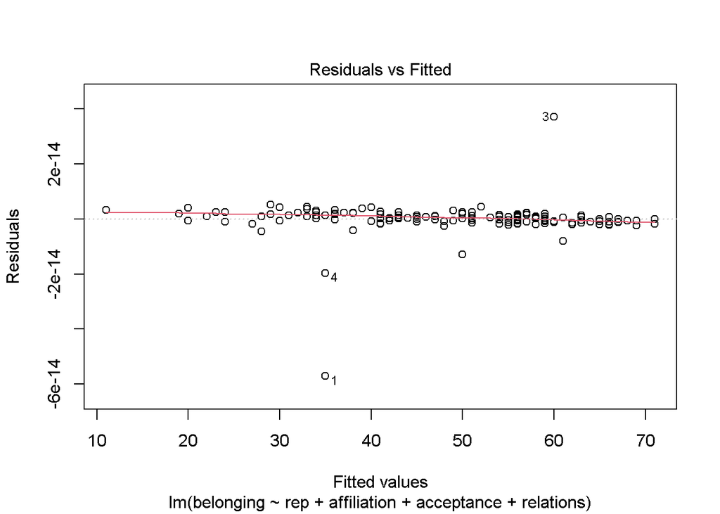

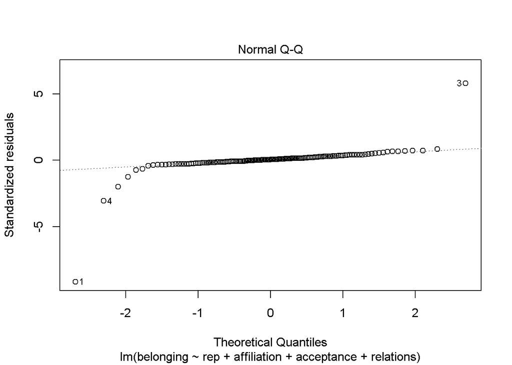

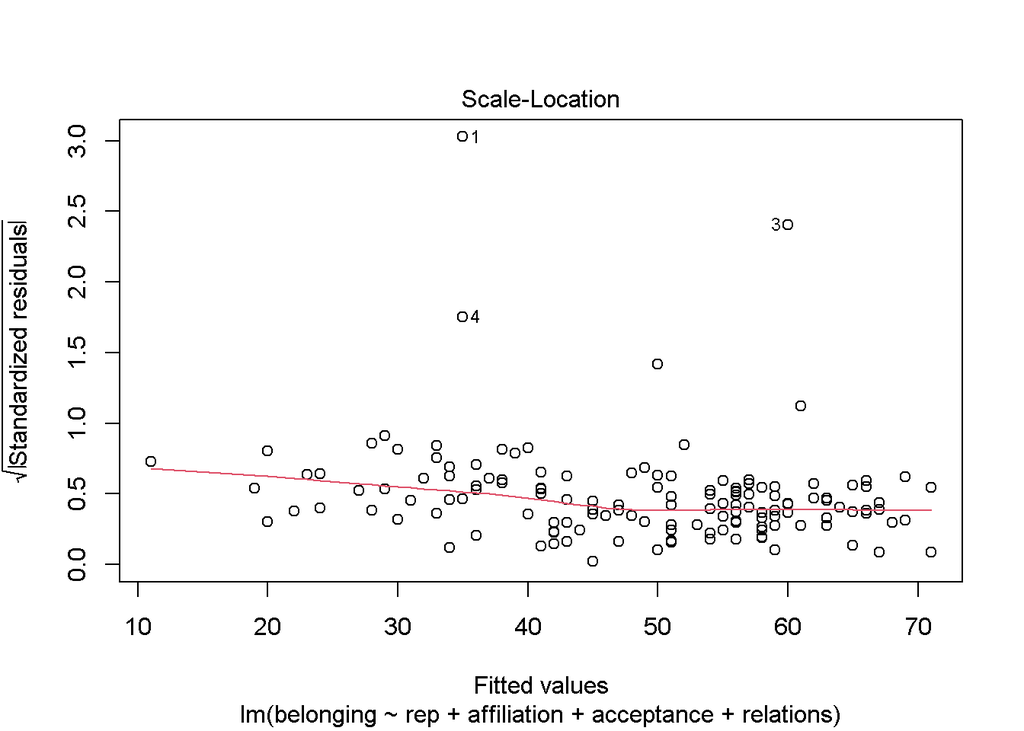

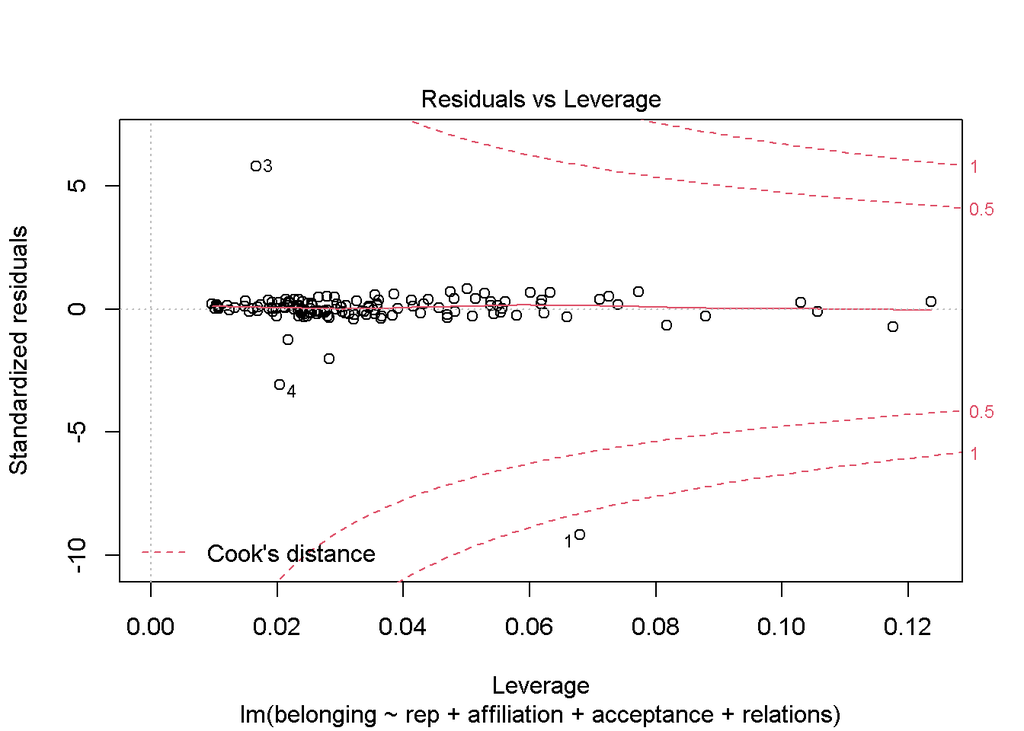

```r
plot(lm1bs24)
```

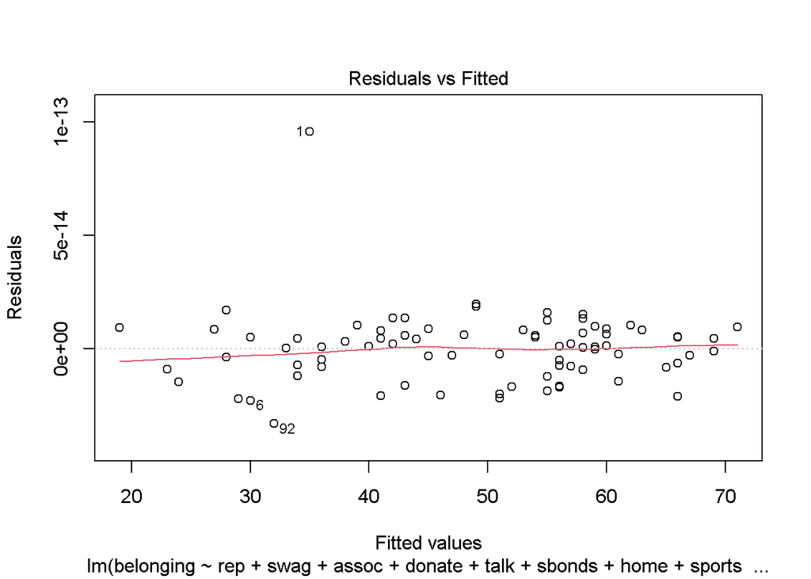

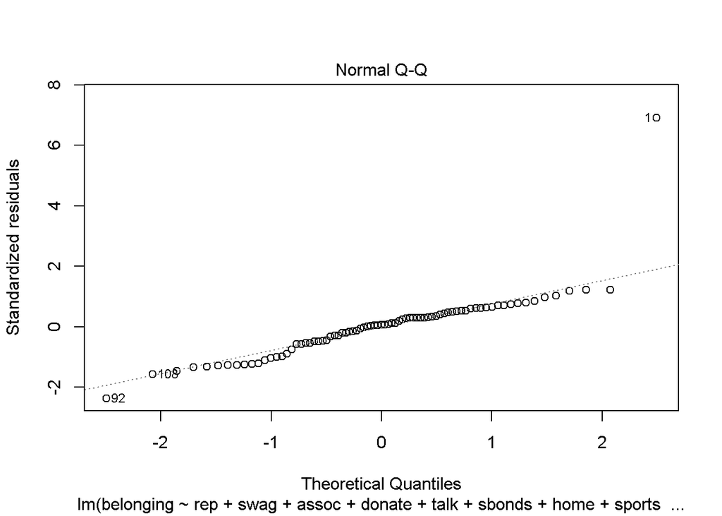

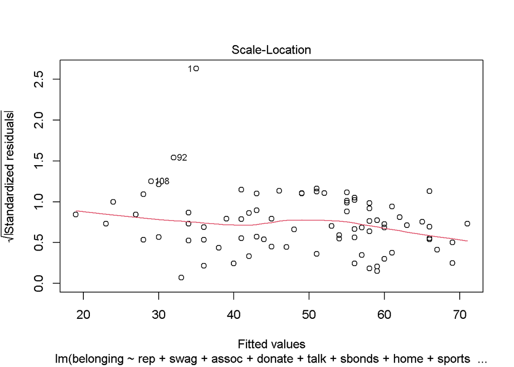

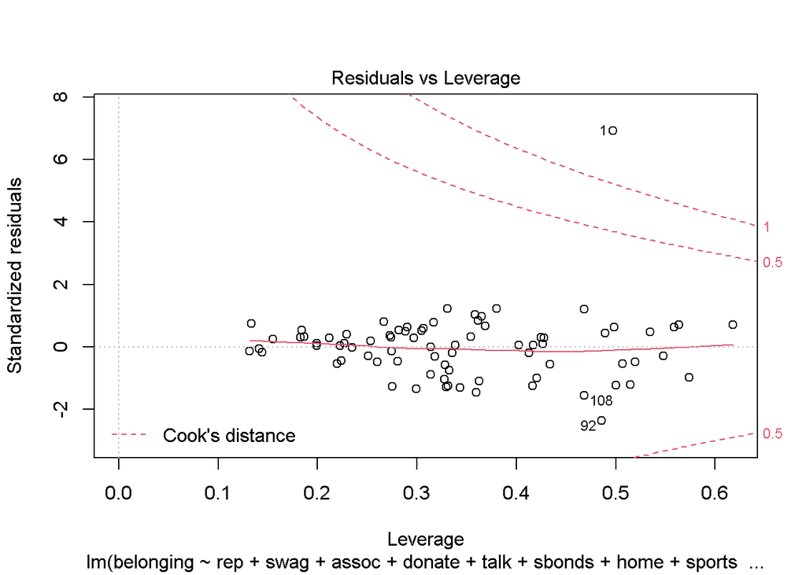

```r
plot(lm2bs21)
```

## Linear assumption is reasonable; the variables seem to hug the residual line meaning that the variances of the error terms are equal; there is an outlier present.

# **Regreassion Tables**

```r
stargazer(lm1bs24, type = "text", title = "Linear Model Table 1", digits = 1)
```

```
##
## Linear Model Table 1
## ==================================================================================
##                                          Dependent variable:
##                     --------------------------------------------------------------
##                                               belonging
## ----------------------------------------------------------------------------------
## rep                                             1.0***
##                                                 (0.0)
##
## affiliation                                     1.0***
##                                                 (0.0)
##
## acceptance                                      1.0***
##                                                 (0.0)
##
## relations                                       1.0***
##                                                 (0.0)
##
## Constant                                       -0.0***
##                                                 (0.0)
##
## ----------------------------------------------------------------------------------
## Observations                                     142
## R2                                               1.0
## Adjusted R2                                      1.0
## Residual Std. Error                         0.0 (df = 137)
## F Statistic         145,215,551,302,637,593,592,268,486,244,080.0*** (df = 4; 137)
## ==================================================================================
## Note:                                                  *p<0.1; **p<0.05; ***p<0.01
```

```r
stargazer(lm2bs21, type = "text", title = "Linear Model Table 1", digits = 1)
```

```
##
## Linear Model Table 1
## ================================================================================
##                                         Dependent variable:
##                     ------------------------------------------------------------
##                                              belonging
## --------------------------------------------------------------------------------
## rep                                            1.0***
##                                                (0.0)
##
## swag                                           1.0***
##                                                (0.0)
##
## assoc                                          1.0***
##                                                (0.0)
##
## donate                                         1.0***
##                                                (0.0)
##
## talk                                           1.0***
##                                                (0.0)
##
## sbonds                                         1.0***
##                                                (0.0)
##
## home                                           1.0***
##                                                (0.0)
##
## sports                                         1.0***
##                                                (0.0)
##
## major                                          1.0***
##                                                (0.0)
##
## ocpride                                        1.0***
##                                                (0.0)
##
## pride                                          1.0***
##                                                (0.0)
##
```

[output cut: 41 more lines]

```
##
## seas                                           0.0***
##                                                (0.0)
##
## Constant                                        0.0
##                                                (0.0)
##
## --------------------------------------------------------------------------------
## Observations                                     79
## R2                                              1.0
## Adjusted R2                                     1.0
## Residual Std. Error                        0.0 (df = 52)
## F Statistic         1,284,751,298,149,871,730,806,422,200,000.0*** (df = 26; 52)
## ================================================================================
## Note:                                                *p<0.1; **p<0.05; ***p<0.01
```

# **Correlation/Observation/P-value Tables**

## lm1

```r
myvars1 <- c("belonging", "rep", "affiliation", "acceptance", "relations")
newdata1 <- mydata[myvars1]
cortab1 <- rcorr(as.matrix(newdata1))
cortab1
```

```
##             belonging  rep affiliation acceptance relations
## belonging        1.00 0.56        0.94       0.87      0.72
## rep              0.56 1.00        0.47       0.54      0.28
## affiliation      0.94 0.47        1.00       0.72      0.56
## acceptance       0.87 0.54        0.72       1.00      0.53
## relations        0.72 0.28        0.56       0.53      1.00
##
## n= 142
##
##
## P
##             belonging rep   affiliation acceptance relations
## belonging             0e+00 0e+00       0e+00      0e+00
## rep         0e+00           0e+00       0e+00      7e-04
## affiliation 0e+00     0e+00             0e+00      0e+00
## acceptance  0e+00     0e+00 0e+00                  0e+00
## relations   0e+00     7e-04 0e+00       0e+00
```

## Affiliation and acceptance are pretty highly correlated at 0.72

## lm2

```r
myvars2 <- c("belonging", "rep", "swag", "assoc", "donate", "talk", "sbonds", "home", "sports", "major", "ocpride",
             "pride", "colors", "ocbelong", "oppgrow", "suppres", "divexp", "satacopp", "unique", "meanact",
             "acsupp", "cultacc", "value", "facsrel", "cares", "appreciated", "seas")
newdata2 <- mydata[myvars2]
cortab2 <- rcorr(as.matrix(newdata2))
cortab2
```

```
##             belonging   rep  swag assoc donate  talk sbonds  home sports major
## belonging        1.00  0.56  0.46  0.68   0.56  0.69   0.69  0.79   0.35  0.50
## rep              0.56  1.00  0.13  0.38   0.24  0.40   0.30  0.43   0.13  0.40
## swag             0.46  0.13  1.00  0.33   0.29  0.29   0.27  0.28   0.34  0.11
## assoc            0.68  0.38  0.33  1.00   0.51  0.56   0.47  0.53   0.15  0.31
## donate           0.56  0.24  0.29  0.51   1.00  0.48   0.28  0.44   0.18  0.10
## talk             0.69  0.40  0.29  0.56   0.48  1.00   0.39  0.55   0.27  0.28
## sbonds           0.69  0.30  0.27  0.47   0.28  0.39   1.00  0.61   0.23  0.34
## home             0.79  0.43  0.28  0.53   0.44  0.55   0.61  1.00   0.24  0.45
## sports           0.35  0.13  0.34  0.15   0.18  0.27   0.23  0.24   1.00  0.20
## major            0.50  0.40  0.11  0.31   0.10  0.28   0.34  0.45   0.20  1.00
## ocpride          0.65  0.24  0.29  0.51   0.42  0.52   0.33  0.54   0.23  0.25
## pride            0.78  0.41  0.34  0.60   0.53  0.63   0.45  0.62   0.25  0.28
## colors           0.70  0.40  0.50  0.46   0.48  0.55   0.31  0.57   0.29  0.24
## ocbelong         0.80  0.34  0.37  0.58   0.49  0.58   0.56  0.70   0.24  0.40
## oppgrow          0.70  0.36  0.27  0.48   0.34  0.41   0.56  0.56   0.07  0.31
## suppres          0.66  0.36  0.23  0.32   0.30  0.41   0.40  0.46   0.23  0.43
## divexp           0.65  0.39  0.18  0.38   0.21  0.39   0.43  0.44   0.19  0.30
## satacopp         0.65  0.31  0.23  0.40   0.44  0.49   0.37  0.44   0.11  0.24
## unique           0.57  0.42  0.09  0.36   0.25  0.27   0.41  0.44   0.13  0.16
## meanact          0.59  0.35  0.09  0.40   0.24  0.33   0.44  0.43   0.04  0.31
## acsupp           0.65  0.33  0.13  0.39   0.36  0.41   0.38  0.50   0.13  0.32
## cultacc          0.44  0.55  0.05  0.19   0.15  0.26   0.18  0.28   0.10  0.31
## value            0.44  0.25  0.11  0.16   0.13  0.22   0.35  0.28   0.03  0.15
## facsrel          0.63  0.21  0.30  0.28   0.22  0.36   0.48  0.47   0.20  0.25
## cares            0.66  0.24  0.30  0.34   0.28  0.34   0.48  0.47   0.25  0.27
## appreciated      0.68  0.25  0.34  0.34   0.35  0.36   0.50  0.50   0.20  0.24
## seas            -0.19 -0.04 -0.15  0.02  -0.17 -0.14  -0.05 -0.13  -0.01  0.02
##             ocpride pride colors ocbelong oppgrow suppres divexp satacopp
## belonging      0.65  0.78   0.70     0.80    0.70    0.66   0.65     0.65
## rep            0.24  0.41   0.40     0.34    0.36    0.36   0.39     0.31
## swag           0.29  0.34   0.50     0.37    0.27    0.23   0.18     0.23
## assoc          0.51  0.60   0.46     0.58    0.48    0.32   0.38     0.40
## donate         0.42  0.53   0.48     0.49    0.34    0.30   0.21     0.44
## talk           0.52  0.63   0.55     0.58    0.41    0.41   0.39     0.49
## sbonds         0.33  0.45   0.31     0.56    0.56    0.40   0.43     0.37
## home           0.54  0.62   0.57     0.70    0.56    0.46   0.44     0.44
## sports         0.23  0.25   0.29     0.24    0.07    0.23   0.19     0.11
## major          0.25  0.28   0.24     0.40    0.31    0.43   0.30     0.24
## ocpride        1.00  0.56   0.55     0.64    0.44    0.39   0.35     0.43
```

[output cut: 229 more lines]

```
## colors      0.0000      0.6450
## ocbelong    0.0000      0.0902
## oppgrow     0.0000      0.2879
## suppres     0.0000      0.0626
## divexp      0.0000      0.4845
## satacopp    0.0000      0.3326
## unique      0.0000      0.0157
## meanact     0.0002      0.1437
## acsupp      0.0000      0.5505
## cultacc     0.0212      0.5369
## value       0.0000      0.0626
## facsrel     0.0000      0.1470
## cares       0.0000      0.2700
## appreciated             0.0036
## seas        0.0036
```

## Affiliation and acceptance questions seem to still have high correlations (0.50s and 0.60s)

# **Decision Trees**

## Making belonging a Factor Variable

```r
mydata$belong[mydata$belonging>= 50] <- 1
mydata$belong[mydata$belonging< 50] <- 0
```

## Create dataframe with statistically significant variables

```r
myvars3 <- c("belong", "rep", "affiliation", "acceptance", "relations", "seas")
newdata3 <- mydata[myvars3]
```

## Tell program the format of the data

```r
newdata4 <- mutate(newdata3, belong=factor(belong), rep= as.numeric(rep), affiliation= as.numeric(affiliation),
                   acceptance= as.numeric(acceptance), relations= as.numeric(relations), seas=factor(seas))
```

## Splitting into training and testing data

```r
set.seed(123)
sample = sample.split(newdata4$belong, SplitRatio = .70)
train = subset(newdata4, sample==TRUE)
test = subset(newdata4, sample == FALSE)
```

## Training the Decision Tree Classifier

```r
tree <- rpart(belong ~.,
              cp = 0.001,
              data = train)
```

## Predictions

```r
tree.belong.predicted <- predict(tree, test, type = 'class')
```

## Confusion Matrix for evaluating the model

```r
confusionMatrix(tree.belong.predicted, test$belong)
```

```
## Confusion Matrix and Statistics
##
##           Reference
## Prediction  0  1
##          0 17  0
##          1  2 23
##
##                Accuracy : 0.9524
##                  95% CI : (0.8384, 0.9942)
##     No Information Rate : 0.5476
##     P-Value [Acc > NIR] : 6.468e-09
##
##                   Kappa : 0.903
##
##  Mcnemar's Test P-Value : 0.4795
##
##             Sensitivity : 0.8947
##             Specificity : 1.0000
##          Pos Pred Value : 1.0000
##          Neg Pred Value : 0.9200
##              Prevalence : 0.4524
##          Detection Rate : 0.4048
##    Detection Prevalence : 0.4048
##       Balanced Accuracy : 0.9474
##
##        'Positive' Class : 0
##
```

## Accuracy is really high, false positives and false negatives are relatively low.

## Visualize the Decision Tree

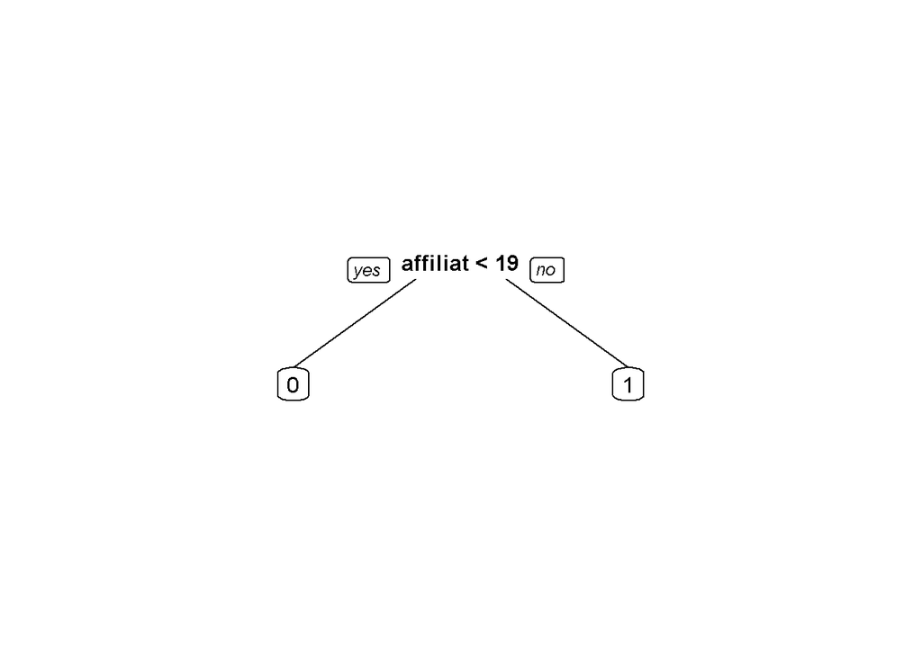

```r
prp(tree)
```

## The variable that lowered the entropy the most was affiliation.

## I decided to add more variables to see if the decision tree would get more complex.

## Create dataframe for a more complex decision tree

```r
myvars4 <- c("belong", "rep", "affiliation", "acceptance", "relations", "seas", "class", "gen", "age", "distance", "imm", "int", "usforeign")
newdata5 <- mydata[myvars4]
```

## Repeating Previous steps

```r
newdata5 <- mutate(newdata5, belong=factor(belong), rep= as.numeric(rep), affiliation= as.numeric(affiliation),
                   acceptance= as.numeric(acceptance), relations= as.numeric(relations), seas=factor(seas), class=factor(class), gen=factor(gen), age= as.numeric(age),
                   distance= as.numeric(distance), imm=factor(imm), int=factor(int), usforeign=factor(usforeign))

set.seed(123)
sample2 = sample.split(newdata5$belong, SplitRatio = .70)
train2 = subset(newdata5, sample2 == TRUE)
test2 = subset(newdata5, sample2 == FALSE)


tree2 <- rpart(belong ~.,
              cp = 0.001,
              data = train2)


tree.belong.predicted2 <- predict(tree2, test2, type = 'class')
```

## Confusion Matrix for evaluating the model

```r
confusionMatrix(tree.belong.predicted2, test2$belong)
```

```
## Confusion Matrix and Statistics
##
##           Reference
## Prediction  0  1
##          0 17  0
##          1  2 23
##
##                Accuracy : 0.9524
##                  95% CI : (0.8384, 0.9942)
##     No Information Rate : 0.5476
##     P-Value [Acc > NIR] : 6.468e-09
##
##                   Kappa : 0.903
##
##  Mcnemar's Test P-Value : 0.4795
##
##             Sensitivity : 0.8947
##             Specificity : 1.0000
##          Pos Pred Value : 1.0000
##          Neg Pred Value : 0.9200
##              Prevalence : 0.4524
##          Detection Rate : 0.4048
##    Detection Prevalence : 0.4048
##       Balanced Accuracy : 0.9474
##
##        'Positive' Class : 0
##
```

## Visualize the Decision Tree

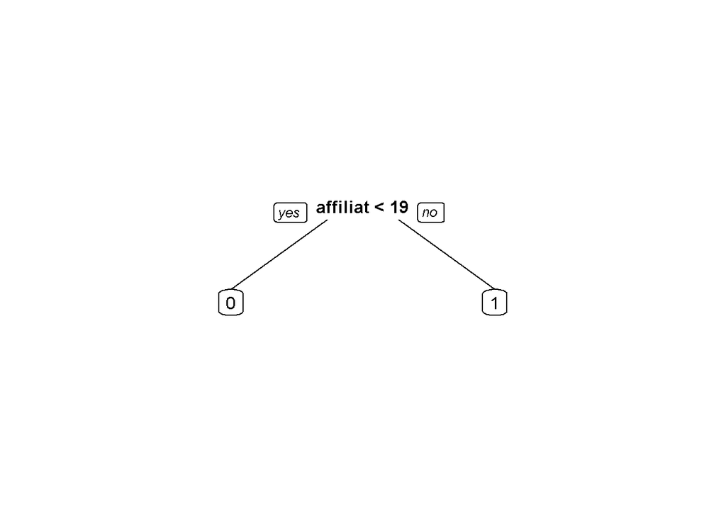

```r
prp(tree2)
```

## I thought that maybe making the threshold for belonging higher would cause changes.

## Making the threshold for belong higher

```r
mydata$belong2[mydata$belonging>= 65] <- 1
mydata$belong2[mydata$belonging< 65] <- 0
```

## Repeated Steps

```r
myvars5 <- c("belong2", "rep", "affiliation", "acceptance", "relations", "seas")
newdata6 <- mydata[myvars5]

newdata6 <- mutate(newdata6, belong2=factor(belong2), rep= as.numeric(rep), affiliation= as.numeric(affiliation),
                   acceptance= as.numeric(acceptance), relations= as.numeric(relations), seas=factor(seas))

set.seed(123)
sample3 = sample.split(newdata6$belong2, SplitRatio = .70)
train3 = subset(newdata6, sample3 ==TRUE)
test3 = subset(newdata6, sample3 == FALSE)

tree3 <- rpart(belong2 ~.,
              cp = 0.001,
              data = train3)

tree.belong.predicted3 <- predict(tree3, test3, type = 'class')
```

## Confusion Matrix for evaluating the model

```r
confusionMatrix(tree.belong.predicted3, test3$belong2)
```

```
## Confusion Matrix and Statistics
##
##           Reference
## Prediction  0  1
##          0 35  1
##          1  3  4
##
##                Accuracy : 0.907
##                  95% CI : (0.7786, 0.9741)
##     No Information Rate : 0.8837
##     P-Value [Acc > NIR] : 0.4296
##
##                   Kappa : 0.6143
##
##  Mcnemar's Test P-Value : 0.6171
##
##             Sensitivity : 0.9211
##             Specificity : 0.8000
##          Pos Pred Value : 0.9722
##          Neg Pred Value : 0.5714
##              Prevalence : 0.8837
##          Detection Rate : 0.8140
##    Detection Prevalence : 0.8372
##       Balanced Accuracy : 0.8605
##
##        'Positive' Class : 0
##
```

## Visualize the Decision Tree

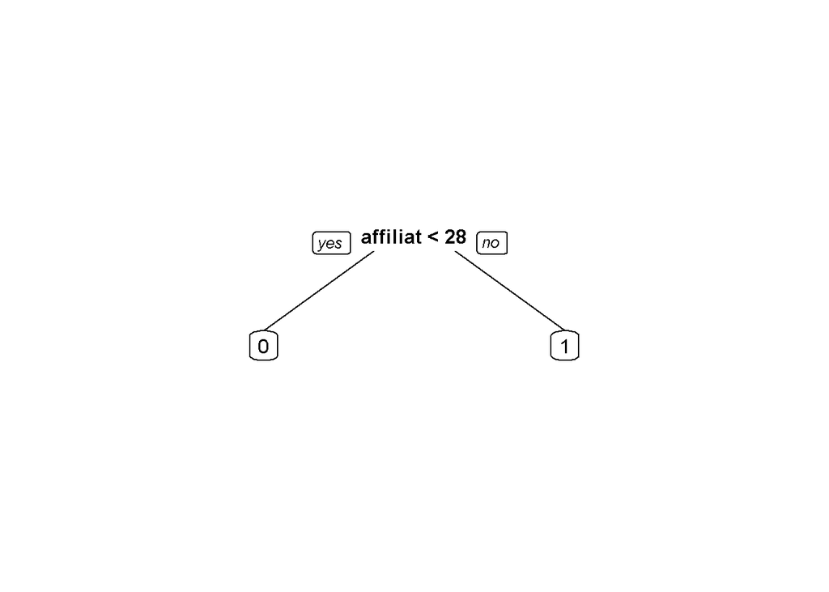

```r
prp(tree3)
```

## Affiliation remains as the predictor that lowers the entropy the most; the only change was that affiliation threshold is at 28 instead of 19.